# Midterm Assignemnt, ME314 2018

Yiming Xu

[figure not shown]

#### Summer School 2018 midsession examination

# ME314 Introduction to Data Science and Big Data

## Suitable for all candidates

### Instructions to candidates

- Complete the assignment by adding your answers directly to the RMarkdown document, knitting the document, and submitting the HTML file to Moodle.
- Time allowed: due 19:00 on Wednesday, 8th August 2018.
- Submit the assignment via [Moodle](https://shortcourses.lse.ac.uk/course/view.php?id=158).

You will need to load the core library for the course textbook and libraries for LDA and KNN:

```r
library(ISLR)
library(MASS)
library(class)
library(caret)
set.seed(201785066) #LSE ID
```

This question should be answered using the `Weekly` data set, which is part of the `ISLR` package. This data contains 1,089 weekly stock returns for 21 years, from the beginning of 1990 to the end of 2010.

1. Produce some numerical and graphical summaries of the `Weekly` data. Do there appear to be any patterns?

   The data is summarised as:
   - Year
   - The year that the observation was recorded
   - Lag1
   - Percentage return for previous week
   - Lag2
   - Percentage return for 2 weeks previous
   - Lag3
   - Percentage return for 3 weeks previous
   - Lag4
   - Percentage return for 4 weeks previous
   - Lag5
   - Percentage return for 5 weeks previous
   - Volume
   - Volume of shares traded (average number of daily shares traded in billions)
   - Today
   - Percentage return for this week
   - Direction
   - A factor with levels Down and Up indicating whether the market had a positive or negative return on a given week

```r
#Open and summarize Weekly
data("Weekly", package = "ISLR")

#To ensure consistency
Weekly$Direction = factor(Weekly$Direction, levels=c("Down", "Up"))
summary(Weekly)
```

```
##       Year           Lag1               Lag2               Lag3
##  Min.   :1990   Min.   :-18.1950   Min.   :-18.1950   Min.   :-18.1950
##  1st Qu.:1995   1st Qu.: -1.1540   1st Qu.: -1.1540   1st Qu.: -1.1580
##  Median :2000   Median :  0.2410   Median :  0.2410   Median :  0.2410
##  Mean   :2000   Mean   :  0.1506   Mean   :  0.1511   Mean   :  0.1472
##  3rd Qu.:2005   3rd Qu.:  1.4050   3rd Qu.:  1.4090   3rd Qu.:  1.4090
##  Max.   :2010   Max.   : 12.0260   Max.   : 12.0260   Max.   : 12.0260
##       Lag4               Lag5              Volume
##  Min.   :-18.1950   Min.   :-18.1950   Min.   :0.08747
##  1st Qu.: -1.1580   1st Qu.: -1.1660   1st Qu.:0.33202
##  Median :  0.2380   Median :  0.2340   Median :1.00268
##  Mean   :  0.1458   Mean   :  0.1399   Mean   :1.57462
##  3rd Qu.:  1.4090   3rd Qu.:  1.4050   3rd Qu.:2.05373
##  Max.   : 12.0260   Max.   : 12.0260   Max.   :9.32821
##      Today          Direction
##  Min.   :-18.1950   Down:484
##  1st Qu.: -1.1540   Up  :605
##  Median :  0.2410
##  Mean   :  0.1499
##  3rd Qu.:  1.4050
##  Max.   : 12.0260
```

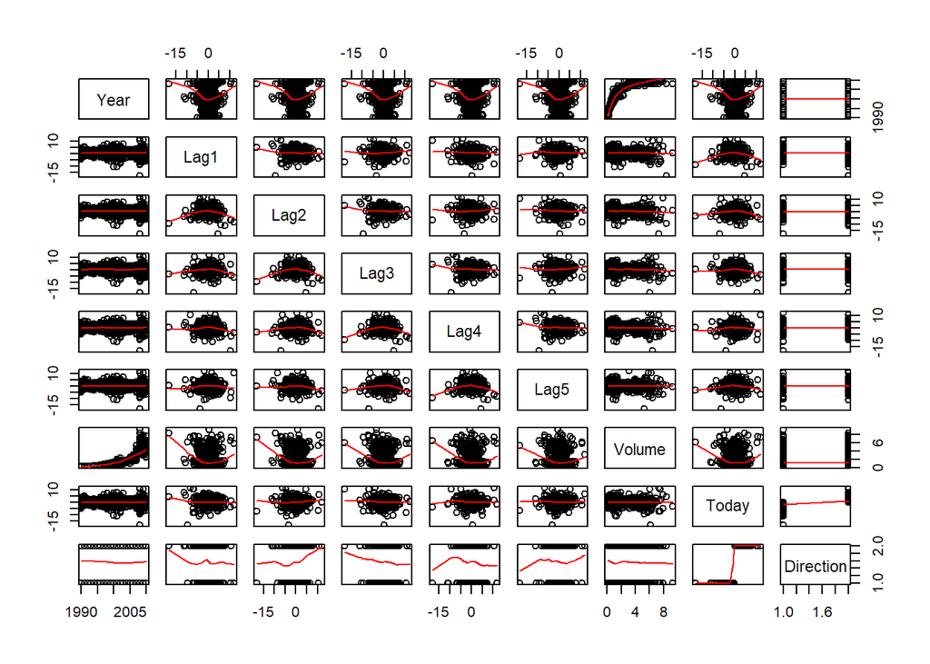

```r
#Comparing pairs of Weekly features...
pairs(Weekly, panel = panel.smooth)
```

```r
#... and checking for covariance
cov(Filter(is.numeric, Weekly))
```

```
##              Year        Lag1       Lag2       Lag3        Lag4
## Year   36.3992836 -0.45916269 -0.4748641 -0.4273326 -0.44326136
## Lag1   -0.4591627  5.55550803 -0.4158894  0.3262333 -0.39651131
## Lag2   -0.4748641 -0.41588937  5.5566475 -0.4213341  0.32482186
## Lag3   -0.4273326  0.32623326 -0.4213341  5.5719696 -0.42006376
## Lag4   -0.4432614 -0.39651131  0.3248219 -0.4200638  5.57091625
## Lag5   -0.4347769 -0.04554365 -0.4035429  0.3380920 -0.42175889
## Volume  8.5674163 -0.25820895 -0.3399858 -0.2758558 -0.24313391
## Today  -0.4615723 -0.41682494  0.3287230 -0.3963662 -0.04353538
##               Lag5     Volume       Today
## Year   -0.43477694  8.5674163 -0.46157229
## Lag1   -0.04554365 -0.2582090 -0.41682494
## Lag2   -0.40354287 -0.3399858  0.32872301
## Lag3    0.33809200 -0.2758558 -0.39636625
## Lag4   -0.42175889 -0.2431339 -0.04353538
## Lag5    5.57566532 -0.2330531  0.06128981
## Volume -0.23305313  2.8447424 -0.13149343
## Today   0.06128981 -0.1314934  5.55510671
```

```r
#And finally seeing the data itself.
head(Weekly)
```

```
##   Year   Lag1   Lag2   Lag3   Lag4   Lag5    Volume  Today Direction
## 1 1990  0.816  1.572 -3.936 -0.229 -3.484 0.1549760 -0.270      Down
## 2 1990 -0.270  0.816  1.572 -3.936 -0.229 0.1485740 -2.576      Down
## 3 1990 -2.576 -0.270  0.816  1.572 -3.936 0.1598375  3.514        Up
## 4 1990  3.514 -2.576 -0.270  0.816  1.572 0.1616300  0.712        Up
## 5 1990  0.712  3.514 -2.576 -0.270  0.816 0.1537280  1.178        Up
## 6 1990  1.178  0.712  3.514 -2.576 -0.270 0.1544440 -1.372      Down
```

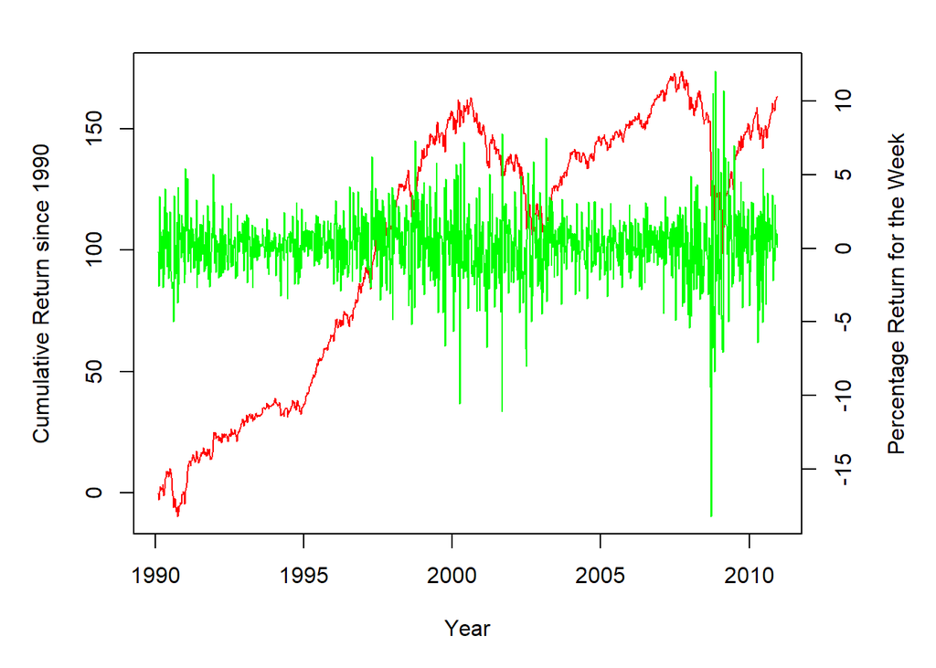

```r
#Note that weekly TS has sometimes more than 52 readings for some years. Analysis show that data is read on Tuesdays
WeeklyTS <- ts(Weekly$Today, frequency = 365.25/7, start=c(1990, 6))
WeeklyTS_cumsum <- ts(cumsum(Weekly$Today), frequency = 365.25/7, start=c(1990, 6))

par(mar = c(5,5,2,5))
plot(WeeklyTS_cumsum, col = "red", xlab = NA, ylab = "Cumulative Return since 1990")
par(new = TRUE)
plot(WeeklyTS, col = "green", ylab = NA, xlab = "Year", axes = FALSE)
axis(side = 4)
mtext(side = 4, line = 3, "Percentage Return for the Week")
```

2. Use the full data set to perform a logistic regression with `Direction` as the response and the five lag variables plus `Volume` as predictors. Use the summary function to print the results.

```r
Weekly_LRfit = glm(Direction ~ Lag1 + Lag2 + Lag3 + Lag4 + Lag5 + Volume,
                   data = Weekly,
                   family = binomial)
summary(Weekly_LRfit)
```

```
##
## Call:
## glm(formula = Direction ~ Lag1 + Lag2 + Lag3 + Lag4 + Lag5 +
##     Volume, family = binomial, data = Weekly)
##
## Deviance Residuals:
##     Min       1Q   Median       3Q      Max
## -1.6949  -1.2565   0.9913   1.0849   1.4579
##
## Coefficients:
##             Estimate Std. Error z value Pr(>|z|)
## (Intercept)  0.26686    0.08593   3.106   0.0019 **
## Lag1        -0.04127    0.02641  -1.563   0.1181
## Lag2         0.05844    0.02686   2.175   0.0296 *
## Lag3        -0.01606    0.02666  -0.602   0.5469
## Lag4        -0.02779    0.02646  -1.050   0.2937
## Lag5        -0.01447    0.02638  -0.549   0.5833
## Volume      -0.02274    0.03690  -0.616   0.5377
## ---
## Signif. codes:  0 '***' 0.001 '**' 0.01 '*' 0.05 '.' 0.1 ' ' 1
##
## (Dispersion parameter for binomial family taken to be 1)
##
##     Null deviance: 1496.2  on 1088  degrees of freedom
## Residual deviance: 1486.4  on 1082  degrees of freedom
## AIC: 1500.4
##
## Number of Fisher Scoring iterations: 4
```

```
Do any of the predictors appear to be statistically significant? If so, which ones?

The predictor, Lag2, appears to be statistically significant at the p < 0.05 level. The other predictors, namely Lag1, Lag3, Lag4, lag5 and Volume do not appear to be statistically significant predictors for Direction.")
```

3. Compute the confusion matrix and overall fraction of correct predictions.

```r
Weekly_LRpred = factor(ifelse(predict.glm(Weekly_LRfit, Weekly, type = 'response') > 0.5, "Up", "Down"))
confusionMatrix(data = Weekly_LRpred, reference = Weekly$Direction, positive = "Up", mode = 'everything')
```

```
## Confusion Matrix and Statistics
##
##           Reference
## Prediction Down  Up
##       Down   54  48
##       Up    430 557
##
##                Accuracy : 0.5611
##                  95% CI : (0.531, 0.5908)
##     No Information Rate : 0.5556
##     P-Value [Acc > NIR] : 0.369
##
##                   Kappa : 0.035
##  Mcnemar's Test P-Value : <2e-16
##
##             Sensitivity : 0.9207
##             Specificity : 0.1116
##          Pos Pred Value : 0.5643
##          Neg Pred Value : 0.5294
##               Precision : 0.5643
##                  Recall : 0.9207
##                      F1 : 0.6997
##              Prevalence : 0.5556
##          Detection Rate : 0.5115
##    Detection Prevalence : 0.9063
##       Balanced Accuracy : 0.5161
##
##        'Positive' Class : Up
##
```

[output not shown]

4. Now fit the logistic regression model using a training data period from 1990 to 2008, with `Lag2` as the only predictor.

   Compute the confusion matrix and the overall fraction of correct predictions for the held out data (that is, the data from 2009 and 2010).

```r
Weekly_train <- Weekly[Weekly$Year < 2009,]
Weekly_test <- Weekly[Weekly$Year > 2008,]
Weekly_train_LRfit = glm(Direction ~ Lag2,
                         data = Weekly_train,
                         family = binomial)
summary(Weekly_train_LRfit)
```

```
##
## Call:
## glm(formula = Direction ~ Lag2, family = binomial, data = Weekly_train)
##
## Deviance Residuals:
##    Min      1Q  Median      3Q     Max
## -1.536  -1.264   1.021   1.091   1.368
##
## Coefficients:
##             Estimate Std. Error z value Pr(>|z|)
## (Intercept)  0.20326    0.06428   3.162  0.00157 **
## Lag2         0.05810    0.02870   2.024  0.04298 *
## ---
## Signif. codes:  0 '***' 0.001 '**' 0.01 '*' 0.05 '.' 0.1 ' ' 1
##
## (Dispersion parameter for binomial family taken to be 1)
##
##     Null deviance: 1354.7  on 984  degrees of freedom
## Residual deviance: 1350.5  on 983  degrees of freedom
## AIC: 1354.5
##
## Number of Fisher Scoring iterations: 4
```

```r
Weekly_train_LRpred = factor(ifelse(predict.glm(Weekly_train_LRfit, Weekly_test, type = 'response') > 0.5, "Up", "Down"))
confusionMatrix(data = Weekly_train_LRpred, reference = Weekly_test$Direction, positive = "Up", mode = 'everything')
```

```
## Confusion Matrix and Statistics
##
##           Reference
## Prediction Down Up
##       Down    9  5
##       Up     34 56
##
##                Accuracy : 0.625
##                  95% CI : (0.5247, 0.718)
##     No Information Rate : 0.5865
##     P-Value [Acc > NIR] : 0.2439
##
##                   Kappa : 0.1414
##  Mcnemar's Test P-Value : 7.34e-06
##
##             Sensitivity : 0.9180
##             Specificity : 0.2093
##          Pos Pred Value : 0.6222
##          Neg Pred Value : 0.6429
##               Precision : 0.6222
##                  Recall : 0.9180
##                      F1 : 0.7417
##              Prevalence : 0.5865
##          Detection Rate : 0.5385
##    Detection Prevalence : 0.8654
##       Balanced Accuracy : 0.5637
##
##        'Positive' Class : Up
##
```

```
The accuracy of the model has increased to 62.5% by using only Lag2 as the predictor, with year 1990-2008 as the training set and year 2009-2010 as the test set.
```

5. Experiment with different combinations of predictors, including possible transformations and interactions, and classification methods.

   Using the same predictors and training/test set as the previous question, we can try different classification methods.

```r
#LDA
Weekly_LDAfit = lda(Direction ~ Lag2,
                   data = Weekly_train)
Weekly_LDAfit
```

```
## Call:
## lda(Direction ~ Lag2, data = Weekly_train)
##
## Prior probabilities of groups:
##      Down        Up
## 0.4477157 0.5522843
##
## Group means:
##             Lag2
## Down -0.03568254
## Up    0.26036581
##
## Coefficients of linear discriminants:
##            LD1
## Lag2 0.4414162
```

```r
Weekly_LDApred = predict(Weekly_LDAfit, Weekly_test)
confusionMatrix(data = Weekly_LDApred$class, reference = Weekly_test$Direction, positive = "Up", mode = 'everything')
```

```
## Confusion Matrix and Statistics
##
##           Reference
## Prediction Down Up
##       Down    9  5
##       Up     34 56
##
##                Accuracy : 0.625
##                  95% CI : (0.5247, 0.718)
##     No Information Rate : 0.5865
##     P-Value [Acc > NIR] : 0.2439
##
##                   Kappa : 0.1414
##  Mcnemar's Test P-Value : 7.34e-06
##
##             Sensitivity : 0.9180
##             Specificity : 0.2093
##          Pos Pred Value : 0.6222
##          Neg Pred Value : 0.6429
##               Precision : 0.6222
##                  Recall : 0.9180
##                      F1 : 0.7417
##              Prevalence : 0.5865
##          Detection Rate : 0.5385
##    Detection Prevalence : 0.8654
##       Balanced Accuracy : 0.5637
##
##        'Positive' Class : Up
##
```

```
Linear discriminant analysis show similar results as logistic regression, with an accuracy of 62.5%. On closer analysis, it appears that the predictions are actually identical. This shows the similarily of the linear approaches. The quadratic discriminant analysis was carried out next.
```

```r
#QDA
Weekly_QDAfit = qda(Direction ~ Lag2,
                   data = Weekly_train,
                   cv = TRUE)
Weekly_QDAfit
```

```
## Call:
## qda(Direction ~ Lag2, data = Weekly_train, cv = TRUE)
##
## Prior probabilities of groups:
##      Down        Up
## 0.4477157 0.5522843
##
## Group means:
##             Lag2
## Down -0.03568254
## Up    0.26036581
```

```r
Weekly_QDApred = predict(Weekly_QDAfit, Weekly_test)
confusionMatrix(data = Weekly_QDApred$class, reference = Weekly_test$Direction, positive = "Up", mode = 'everything')
```

```
## Confusion Matrix and Statistics
##
##           Reference
## Prediction Down Up
##       Down    0  0
##       Up     43 61
##
##                Accuracy : 0.5865
##                  95% CI : (0.4858, 0.6823)
##     No Information Rate : 0.5865
##     P-Value [Acc > NIR] : 0.5419
##
##                   Kappa : 0
##  Mcnemar's Test P-Value : 1.504e-10
##
##             Sensitivity : 1.0000
##             Specificity : 0.0000
##          Pos Pred Value : 0.5865
##          Neg Pred Value :    NaN
##               Precision : 0.5865
##                  Recall : 1.0000
##                      F1 : 0.7394
##              Prevalence : 0.5865
##          Detection Rate : 0.5865
##    Detection Prevalence : 1.0000
##       Balanced Accuracy : 0.5000
##
##        'Positive' Class : Up
##
```

```
Compared to LDA, QHA has a lower accuracy. It appears that QDA simply opted to predict `Up` for all cases, and is thus identical to the null model. This is shown by its sensitivity of 1 and specificity of 0. QDA is unsuitable for classification for this system.

For k-nearest neighbour, the parameter `k` could be varied. The model was first tested at `k = 1 and 10`, before optimizing using the caret package.
```

```r
#KNN
Weekly_KNNfit = knn(train = subset(Weekly_train, select=c("Lag2")),
                    test = subset(Weekly_test, select=c("Lag2")),
                    cl = Weekly_train$Direction,
                    k = 1)
confusionMatrix(data = Weekly_KNNfit, reference = Weekly_test$Direction, positive = "Up", mode = 'everything')
```

```
## Confusion Matrix and Statistics
##
##           Reference
## Prediction Down Up
##       Down   21 30
##       Up     22 31
##
##                Accuracy : 0.5
##                  95% CI : (0.4003, 0.5997)
##     No Information Rate : 0.5865
##     P-Value [Acc > NIR] : 0.9700
##
##                   Kappa : -0.0033
##  Mcnemar's Test P-Value : 0.3317
##
##             Sensitivity : 0.5082
##             Specificity : 0.4884
##          Pos Pred Value : 0.5849
##          Neg Pred Value : 0.4118
##               Precision : 0.5849
##                  Recall : 0.5082
##                      F1 : 0.5439
##              Prevalence : 0.5865
##          Detection Rate : 0.2981
##    Detection Prevalence : 0.5096
##       Balanced Accuracy : 0.4983
##
##        'Positive' Class : Up
##
```

```
For `k = 1`, The accuracy was in effect a coin toss at 50%. This would be worse than a null model of `Up` only.
```

```r
#KNN
Weekly_KNNfit = knn(train = subset(Weekly_train, select=c("Lag2")),
                    test = subset(Weekly_test, select=c("Lag2")),
                    cl = Weekly_train$Direction,
                    k = 10)
confusionMatrix(data = Weekly_KNNfit, reference = Weekly_test$Direction, positive = "Up", mode = 'everything')
```

```
## Confusion Matrix and Statistics
##
##           Reference
## Prediction Down Up
##       Down   18 18
##       Up     25 43
##
##                Accuracy : 0.5865
##                  95% CI : (0.4858, 0.6823)
##     No Information Rate : 0.5865
##     P-Value [Acc > NIR] : 0.5419
##
##                   Kappa : 0.1266
##  Mcnemar's Test P-Value : 0.3602
##
##             Sensitivity : 0.7049
##             Specificity : 0.4186
##          Pos Pred Value : 0.6324
##          Neg Pred Value : 0.5000
##               Precision : 0.6324
##                  Recall : 0.7049
##                      F1 : 0.6667
##              Prevalence : 0.5865
##          Detection Rate : 0.4135
##    Detection Prevalence : 0.6538
##       Balanced Accuracy : 0.5618
##
##        'Positive' Class : Up
##
```

```
At `k = 10`, the kNN model performed identically to the null model.
```

```r
fitControl <- trainControl(## 10-fold CV
                           method = "repeatedcv",
                           number = 10,
                           ## repeated ten times
                           repeats = 10)

knnFit <- train(Direction ~ Lag2, data = Weekly_train,
                 method = "knn",
                 trControl = fitControl,
                 tuneLength = 20)
knnFit
```

```
## k-Nearest Neighbors
##
## 985 samples
##   1 predictor
##   2 classes: 'Down', 'Up'
##
## No pre-processing
## Resampling: Cross-Validated (10 fold, repeated 10 times)
## Summary of sample sizes: 886, 887, 886, 887, 886, 887, ...
## Resampling results across tuning parameters:
##
##   k   Accuracy   Kappa
##    5  0.4898495  -0.042274306
##    7  0.5108494  -0.003534080
##    9  0.5073852  -0.012167924
##   11  0.5159413   0.004306948
##   13  0.5244294   0.019369371
##   15  0.5412827   0.051922198
##   17  0.5450706   0.058533484
##   19  0.5395850   0.046341245
##   21  0.5444418   0.055168819
##   23  0.5524692   0.070702193
##   25  0.5560395   0.076964927
##   27  0.5582556   0.080755160
##   29  0.5567149   0.078130424
##   31  0.5565271   0.078641531
##   33  0.5588730   0.084061482
##   35  0.5570414   0.081112198
##   37  0.5544027   0.075624249
##   39  0.5516590   0.070431224
##   41  0.5501417   0.066356813
##   43  0.5441594   0.052815061
##
## Accuracy was used to select the optimal model using the largest value.
## The final value used for the model was k = 33.
```

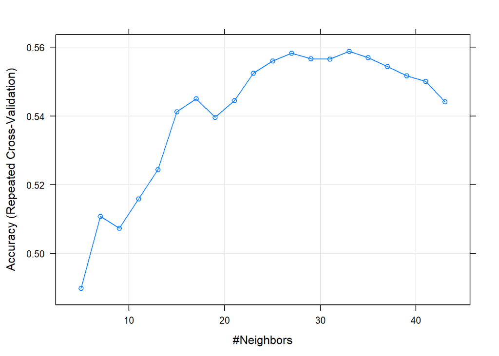

```r
plot(knnFit)
```

```r
#KNN
Weekly_KNNfit = knn(train = subset(Weekly_train, select=c("Lag2")),
                    test = subset(Weekly_test, select=c("Lag2")),
                    cl = Weekly_train$Direction,
                    k = 33)
confusionMatrix(data = Weekly_KNNfit, reference = Weekly_test$Direction, positive = "Up", mode = 'everything')
```

```
## Confusion Matrix and Statistics
##
##           Reference
## Prediction Down Up
##       Down   21 25
##       Up     22 36
##
##                Accuracy : 0.5481
##                  95% CI : (0.4474, 0.6459)
##     No Information Rate : 0.5865
##     P-Value [Acc > NIR] : 0.8152
##
##                   Kappa : 0.0777
##  Mcnemar's Test P-Value : 0.7705
##
##             Sensitivity : 0.5902
##             Specificity : 0.4884
##          Pos Pred Value : 0.6207
##          Neg Pred Value : 0.4565
##               Precision : 0.6207
##                  Recall : 0.5902
##                      F1 : 0.6050
##              Prevalence : 0.5865
##          Detection Rate : 0.3462
##    Detection Prevalence : 0.5577
##       Balanced Accuracy : 0.5393
##
##        'Positive' Class : Up
##
```

```
Even after optimization with caret, the kNN model has failed to improve over the null model. This shows that kNN is not a suitable model for this type of classification. We could next investigation the interaction between the parameters.
```

```r
Weekly_Interaction_LRfit = glm(Direction ~ Lag1 * Lag2 * Lag3 * Lag4 * Lag5 * Volume,
                   data = Weekly_train,
                   family = binomial)
summary(Weekly_Interaction_LRfit)
```

```
##
## Call:
## glm(formula = Direction ~ Lag1 * Lag2 * Lag3 * Lag4 * Lag5 *
##     Volume, family = binomial, data = Weekly_train)
##
## Deviance Residuals:
##     Min       1Q   Median       3Q      Max
## -2.0332  -1.2303   0.8259   1.0614   1.6013
##
## Coefficients:
##                                   Estimate Std. Error z value Pr(>|z|)
## (Intercept)                      0.2964492  0.1030234   2.877  0.00401 **
## Lag1                            -0.0337966  0.0565207  -0.598  0.54987
## Lag2                             0.0423933  0.0581492   0.729  0.46598
## Lag3                            -0.0109297  0.0566198  -0.193  0.84693
## Lag4                            -0.0530895  0.0578269  -0.918  0.35858
## Lag5                            -0.0949614  0.0578646  -1.641  0.10078
## Volume                          -0.0622140  0.0692401  -0.899  0.36891
## Lag1:Lag2                       -0.0400998  0.0290642  -1.380  0.16768
## Lag1:Lag3                       -0.0370744  0.0299252  -1.239  0.21538
## Lag2:Lag3                       -0.0005412  0.0288835  -0.019  0.98505
## Lag1:Lag4                       -0.0060507  0.0270091  -0.224  0.82274
## Lag2:Lag4                       -0.0211558  0.0306113  -0.691  0.48950
## Lag3:Lag4                        0.0341596  0.0270225   1.264  0.20619
## Lag1:Lag5                       -0.0194132  0.0280856  -0.691  0.48943
## Lag2:Lag5                       -0.0059219  0.0276866  -0.214  0.83063
## Lag3:Lag5                        0.0100649  0.0302032   0.333  0.73895
## Lag4:Lag5                       -0.0432133  0.0261821  -1.650  0.09884 .
## Lag1:Volume                     -0.0379147  0.0399861  -0.948  0.34303
## Lag2:Volume                      0.0252687  0.0409900   0.616  0.53759
## Lag3:Volume                      0.0093438  0.0375597   0.249  0.80354
## Lag4:Volume                      0.0129476  0.0391839   0.330  0.74107
## Lag5:Volume                      0.0471303  0.0384294   1.226  0.22004
## Lag1:Lag2:Lag3                   0.0089432  0.0148934   0.600  0.54819
## Lag1:Lag2:Lag4                  -0.0237403  0.0122584  -1.937  0.05279 .
## Lag1:Lag3:Lag4                  -0.0248023  0.0145826  -1.701  0.08898 .
## Lag2:Lag3:Lag4                  -0.0090151  0.0141983  -0.635  0.52547
## Lag1:Lag2:Lag5                  -0.0121957  0.0126997  -0.960  0.33690
## Lag1:Lag3:Lag5                  -0.0235403  0.0133936  -1.758  0.07882 .
## Lag2:Lag3:Lag5                  -0.0113608  0.0127804  -0.889  0.37404
```

[output cut: 30 more lines]

```
## Lag1:Lag2:Lag3:Lag5:Volume      -0.0006154  0.0058108  -0.106  0.91565
## Lag1:Lag2:Lag4:Lag5:Volume       0.0107664  0.0058867   1.829  0.06741 .
## Lag1:Lag3:Lag4:Lag5:Volume       0.0072033  0.0061079   1.179  0.23826
## Lag2:Lag3:Lag4:Lag5:Volume      -0.0101444  0.0066374  -1.528  0.12642
## Lag1:Lag2:Lag3:Lag4:Lag5:Volume  0.0033596  0.0019900   1.688  0.09137 .
## ---
## Signif. codes:  0 '***' 0.001 '**' 0.01 '*' 0.05 '.' 0.1 ' ' 1
##
## (Dispersion parameter for binomial family taken to be 1)
##
##     Null deviance: 1354.7  on 984  degrees of freedom
## Residual deviance: 1274.3  on 921  degrees of freedom
## AIC: 1402.3
##
## Number of Fisher Scoring iterations: 12
```

```r
Weekly_Interaction_LRpred = factor(ifelse(predict.glm(Weekly_Interaction_LRfit, Weekly_test, type = 'response') > 0.5, "Up", "Down"))
confusionMatrix(data = Weekly_Interaction_LRpred, reference = Weekly_test$Direction, positive = "Up", mode = 'everything')
```

```
## Confusion Matrix and Statistics
##
##           Reference
## Prediction Down Up
##       Down   22 21
##       Up     21 40
##
##                Accuracy : 0.5962
##                  95% CI : (0.4954, 0.6913)
##     No Information Rate : 0.5865
##     P-Value [Acc > NIR] : 0.4626
##
##                   Kappa : 0.1674
##  Mcnemar's Test P-Value : 1.0000
##
##             Sensitivity : 0.6557
##             Specificity : 0.5116
##          Pos Pred Value : 0.6557
##          Neg Pred Value : 0.5116
##               Precision : 0.6557
##                  Recall : 0.6557
##                      F1 : 0.6557
##              Prevalence : 0.5865
##          Detection Rate : 0.3846
##    Detection Prevalence : 0.5865
##       Balanced Accuracy : 0.5837
##
##        'Positive' Class : Up
##
```

[output not shown]

```r
Weekly_Interaction_LinearRfit = lm(Today ~ Lag1 + Lag2 + Lag3 + Lag4 + Lag5,
                   data = Weekly_train)
summary(Weekly_Interaction_LinearRfit)
```

```
##
## Call:
## lm(formula = Today ~ Lag1 + Lag2 + Lag3 + Lag4 + Lag5, data = Weekly_train)
##
## Residuals:
##     Min      1Q  Median      3Q     Max
## -18.878  -1.237   0.122   1.225  11.452
##
## Coefficients:
##               Estimate Std. Error t value Pr(>|t|)
## (Intercept)  0.1406206  0.0728478   1.930   0.0539 .
## Lag1        -0.0817523  0.0320893  -2.548   0.0110 *
## Lag2         0.0604830  0.0321979   1.878   0.0606 .
## Lag3        -0.0550207  0.0321571  -1.711   0.0874 .
## Lag4        -0.0081527  0.0321425  -0.254   0.7998
## Lag5         0.0009869  0.0320290   0.031   0.9754
## ---
## Signif. codes:  0 '***' 0.001 '**' 0.01 '*' 0.05 '.' 0.1 ' ' 1
##
## Residual standard error: 2.268 on 979 degrees of freedom
## Multiple R-squared:  0.01515,    Adjusted R-squared:  0.01012
## F-statistic: 3.012 on 5 and 979 DF,  p-value: 0.01049
```

```
We could remove `Lag4` and `Lag5` as they are far from statistical significance.
```

```r
Weekly_Interaction_LinearRfit2 = lm(Today ~ Lag1 + Lag2 + Lag3,
                   data = Weekly_train)
summary(Weekly_Interaction_LinearRfit2)
```

```
##
## Call:
## lm(formula = Today ~ Lag1 + Lag2 + Lag3, data = Weekly_train)
##
## Residuals:
##      Min       1Q   Median       3Q      Max
## -18.8845  -1.2466   0.1315   1.2336  11.3641
##
## Coefficients:
##             Estimate Std. Error t value Pr(>|t|)
## (Intercept)  0.13967    0.07253   1.926   0.0544 .
## Lag1        -0.08130    0.03201  -2.540   0.0112 *
## Lag2         0.05995    0.03206   1.870   0.0618 .
## Lag3        -0.05431    0.03196  -1.699   0.0896 .
## ---
## Signif. codes:  0 '***' 0.001 '**' 0.01 '*' 0.05 '.' 0.1 ' ' 1
##
## Residual standard error: 2.265 on 981 degrees of freedom
## Multiple R-squared:  0.01509,    Adjusted R-squared:  0.01207
## F-statistic: 5.008 on 3 and 981 DF,  p-value: 0.001887
```

```r
Weekly_Interaction_LinearRpred = factor(ifelse(predict.lm(Weekly_Interaction_LinearRfit2, Weekly_test) > 0, "Up", "Down"))
confusionMatrix(data = Weekly_Interaction_LinearRpred, reference = Weekly_test$Direction, positive = "Up", mode = 'everything')
```

```
## Confusion Matrix and Statistics
##
##           Reference
## Prediction Down Up
##       Down   19 18
##       Up     24 43
##
##                Accuracy : 0.5962
##                  95% CI : (0.4954, 0.6913)
##     No Information Rate : 0.5865
##     P-Value [Acc > NIR] : 0.4626
##
##                   Kappa : 0.1499
##  Mcnemar's Test P-Value : 0.4404
##
##             Sensitivity : 0.7049
##             Specificity : 0.4419
##          Pos Pred Value : 0.6418
##          Neg Pred Value : 0.5135
##               Precision : 0.6418
##                  Recall : 0.7049
##                      F1 : 0.6719
##              Prevalence : 0.5865
##          Detection Rate : 0.4135
##    Detection Prevalence : 0.6442
##       Balanced Accuracy : 0.5734
##
##        'Positive' Class : Up
##
```

[output not shown]